# Temporal variation in the biochemical ecology of lower trophic levels in the Northern California Current - ScienceDirect

Brought to you by:[Reed College Library](https://library.reed.edu/)

- [View **PDF**](https://www-sciencedirect-com.reed.idm.oclc.org/science/article/pii/S007966111630252X/pdfft?md5=849501e4aaaf59b205e5065a44b75cac&pid=1-s2.0-S007966111630252X-main.pdf)
- [View Open Manuscript](https://www-sciencedirect-com.reed.idm.oclc.org/science/article/am/pii/S007966111630252X)

## [Progress in Oceanography](https://www-sciencedirect-com.reed.idm.oclc.org/journal/progress-in-oceanography)

[Volume 155](https://www-sciencedirect-com.reed.idm.oclc.org/journal/progress-in-oceanography/vol/155/suppl/C), June 2017, Pages 1-12

# Temporal variation in the biochemical ecology of lower trophic levels in the Northern California Current

https://doi.org/10.1016/j.pocean.2017.05.003[Get rights and content](https://s100.copyright.com/AppDispatchServlet?publisherName=ELS&contentID=S007966111630252X&orderBeanReset=true)

## Highlights

- •

  Lipid quantity and quality covary with plankton species composition in California Current.
- •

  Timing of seasonal transitions in copepod biochemistry reflects shifts in phytoplankton.
- •

  Plankton biomass 5x and lipid levels 2x greater in spring/summer than fall/winter.
- •

  Seasonal variation in contribution of the [essential fatty acid](https://www-sciencedirect-com.reed.idm.oclc.org/topics/agricultural-and-biological-sciences/essential-fatty-acid) EPA more pronounced than for DHA.
- •

  Interactions between copepods and their prey regulate copepod nutritional quality.

## Abstract

There is strong correlative evidence that variation in the growth and survival of secondary consumers is related to the copepod species composition within the Northern California Current. Potential mechanisms driving these correlations include: (1) enhanced growth and survival of secondary consumers when lipid-rich, boreal copepod species are abundant, with cascading effects on higher trophic levels; (2) the regulation of growth and condition of primary and secondary consumers by the relative proportion of certain essential fatty acids (FAs) in primary producers; or (3) a combination of these factors. Disentangling the relative importance of taxonomic composition, lipid quantity, and FA composition on the nutritional quality of copepods requires detailed information on both the consumer and primary producers. Therefore, we collected phytoplankton and copepods at an oceanographic station for 19 months and completed species community analyses and generated detailed lipid profiles, including lipid classes and FAs, for both groups. There was strong covariation between species and biochemistry within and across trophic levels and distinct seasonal differences. The amount of total lipid within both the phytoplankton and copepod communities was twice as high in spring and summer than in fall and winter, and certain FAs, such as diatom indicators 20:5ω3 and 16:1ω7, comprised a greater proportion of the FA pool in spring and summer. Indicators of bacterial production within the copepod community were proportionally twice as high during fall and winter than spring and summer. Seasonal transitions in copepod FA composition were consistently offset from transitions in copepod species composition by approximately two weeks. The timing of the seasonal transition in copepod FAs reflected seasonal shifts in the species composition and/or biochemistry of primary producers more than seasonal shifts in the copepod species composition. These results emphasize the importance of interactions between the copepod community and their available phytoplankton prey in regulating the nutritional quality of primary consumers.

- [Previous article in issue](https://www-sciencedirect-com.reed.idm.oclc.org/science/article/pii/S0079661117301970)
- [Next article in issue](https://www-sciencedirect-com.reed.idm.oclc.org/science/article/pii/S0079661117301659)

## Keywords

Biochemical ecology

Lower trophic levels

Lipids and fatty acids

Northern California Current, Oregon, USA

## 1. Introduction

The influence of environmental variation on the productivity of marine species has long been recognized (Mantua et al., 1997, McGowan et al., 1998) although mechanistic linkages remain poorly understood (Botsford, 2001, Beamish and Noakes, 2002). Strong relationships between variation in [primary production](https://www-sciencedirect-com.reed.idm.oclc.org/topics/agricultural-and-biological-sciences/primary-production), which is largely regulated by light, nutrients, and temperature, and the abundance of zooplankton and fish are often cited as evidence for “bottom-up” regulation (Ware and Thomson, 2005, El-Sabaawi et al., 2012, Batten et al., 2016, Kvile et al., 2016). Seasonal and interannual variation in the species composition and abundance of primary consumers, such as copepods, can also be directly linked to environmental (Peterson and Miller, 1975) and [climate variability](https://www-sciencedirect-com.reed.idm.oclc.org/topics/earth-and-planetary-sciences/climate-variation), such as the [Pacific Decadal Oscillation](https://www-sciencedirect-com.reed.idm.oclc.org/topics/earth-and-planetary-sciences/pacific-decadal-oscillation) (Hooff and Peterson, 2006, Keister et al., 2011, Peterson et al., 2014) and El Niño-Southern Oscillation (Peterson et al., 2002, Fisher et al., 2015). There is also evidence that large-scale shifts in the composition and abundance of boreal marine fish communities are related to variation in the nutritional quality of their prey, i.e., the relative abundance of certain fatty acids (FAs), in addition to, and perhaps more than, the quantity of lower [trophic level](https://www-sciencedirect-com.reed.idm.oclc.org/topics/agricultural-and-biological-sciences/trophic-level) production (Litzow et al., 2006).

Variability in productivity and community structure of intermediate trophic levels, such as forage fish and other secondary consumers, has been related to lipid quantity and quality of primary producers (St. John and Lund, 1996, Brett and Muller-Navarra, 1997, Litzow et al., 2006). Potential mechanisms for relationships between enhanced productivity and growth in these intermediate trophic levels and the lipid quantity and composition within lower trophic levels include greater [energy density](https://www-sciencedirect-com.reed.idm.oclc.org/topics/earth-and-planetary-sciences/flux-density) or more efficient energy transfer associated with lipid-rich prey that contain high levels of [polyunsaturated FAs.](https://www-sciencedirect-com.reed.idm.oclc.org/topics/agricultural-and-biological-sciences/polyunsaturated-fatty-acid) Litzow et al. (2006) posit that observed species community shifts in boreal oceans may be initiated by changes in the relative amounts of certain FAs, such as docosahexaenoic (DHA: 22:6ω3) and eicosapentaenoic (EPA: 20:5ω3) acids, in primary producers that differentially impact growth and survival of lipid-rich and lipid-poor consumers. Disentangling the relative importance of prey species composition, lipid quantity, and lipid composition on growth and productivity requires an understanding of the temporal variation in each of those factors across trophic levels (Budge et al., 2014). While there is a growing body of information on how species composition responds to seasonal and environmental variation (Mackas et al., 2001, Hooff and Peterson, 2006, Du and Peterson, 2014a, Du et al., 2015, Fontana et al., 2016), less is known about the biochemical responses of those communities to environmental variability (El-Sabaawi et al., 2009a, El-Sabaawi et al., 2009b, Connelly et al., 2016).

The Northern California Current is a region of seasonal upwelling where coastal winds shift from predominantly northwesterly, upwelling favorable during spring and summer to southwesterly, downwelling favorable during fall and winter. The coastal copepod community within the Northern California Current consistently oscillates between one dominated by warmer water, sub-tropical, “southern” species transported from the south during fall and winter and one dominated by lipid-rich, boreal, “northern” species transported from the north during the spring and summer upwelling period (Morgan et al., 2003, Hooff and Peterson, 2006). This variation in copepod species composition is influenced by the strength of the poleward-flowing Davidson Current in winter and southward coastal flows in summer associated with coastal upwelling. There are also oscillations in copepod community composition on longer temporal scales that correlate with regional-scale oceanographic indices, such as the Pacific Decadal Oscillation and [El Niño Southern Oscillation](https://www-sciencedirect-com.reed.idm.oclc.org/topics/earth-and-planetary-sciences/el-nino-southern-oscillation) (Fisher et al., 2015), likely through variations in water transport within the coastal branch of the Northern California Current (Keister et al., 2011): a lipid-rich community dominates during negative (cold) phase of the PDO and a lipid-poor community during positive (warm) phase of the PDO.

There is strong correlative evidence that variation in the distribution, growth, and survival of higher trophic levels is related to the copepod species composition in Northern California Current coastal waters. For example, changes in the spatial distribution (Bi et al., 2011), growth and survival of juvenile Pacific salmon *[Oncorhynchus](https://www-sciencedirect-com.reed.idm.oclc.org/topics/agricultural-and-biological-sciences/oncorhynchus)* spp. (Peterson and Schwing, 2003, Burke et al., 2013, Miller et al., 2014), early growth and survival of [northern anchovy](https://www-sciencedirect-com.reed.idm.oclc.org/topics/agricultural-and-biological-sciences/californian-anchovy) *Engraulis mordax* (Litz et al., 2008, Takahashi et al., 2012), recruitment of sablefish *[Anoplopoma fimbria](https://www-sciencedirect-com.reed.idm.oclc.org/topics/agricultural-and-biological-sciences/anoplopoma-fimbria)* (MacFarlane and Beamish, 1992, Schirripa and Colbert, 2006), and seabird reproductive success (Sydeman et al., 2014) are correlated with copepod community composition. A potential mechanism responsible for these correlations (first proposed by Peterson and Hooff, 2005) is that a copepod community dominated by lipid-rich, boreal species supports greater growth and survival of early stages of forage fishes, such as northern anchovy, that directly feed on copepods and can have cascading effects on higher trophic levels (Bi et al., 2011, Takahashi et al., 2012). It is also likely that enhanced growth and survival of larval and juvenile fishes are due to greater availability of certain FAs, such as DHA and EPA, in their prey under certain environmental conditions (St. John and Lund, 1996, Copeman et al., 2002, Copeman and Laurel, 2010).

Lipid content can vary among copepod species, including contributions of [neutral lipids](https://www-sciencedirect-com.reed.idm.oclc.org/topics/agricultural-and-biological-sciences/triglyceride), such as [wax esters](https://www-sciencedirect-com.reed.idm.oclc.org/topics/agricultural-and-biological-sciences/wax-ester) and triacylglycerols, and polar lipids, such as [phospholipids](https://www-sciencedirect-com.reed.idm.oclc.org/topics/earth-and-planetary-sciences/phospholipid) and sterols (Lee et al., 2006, Kattner et al., 2007). Many boreal calanoid copepods store lipids as wax esters, which is hypothesized to be an adaptation to an herbivorous life history in regions with pulsed phytoplankton production such as coastal upwelling areas. However, there can be extensive variability in the proportion of wax esters within and among species, and some copepod species rely on triacylglycerols for storage, which appears to be more common in species that are active throughout the year (Kattner and Hagen, 2009). The proportion of [phospholipids](https://www-sciencedirect-com.reed.idm.oclc.org/topics/agricultural-and-biological-sciences/phospholipid), which are the principal constituents of structural membranes, tends to vary less across species but phospholipids can contain high levels of the [essential FAs](https://www-sciencedirect-com.reed.idm.oclc.org/topics/agricultural-and-biological-sciences/essential-fatty-acid) EPA and DHA (Kattner and Hagen, 2009). A greater understanding of the seasonal and interannual variation in the lipid class quantity and composition of the coastal copepod community within the Northern California Current is needed to understand dietary effects on higher trophic levels.

There are at least three primary factors that can influence the lipid quantity and quality of the copepod community, including the copepod species composition and the species and lipid composition of their prey. The relative importance of each of these factors in regulating the nutritional quality of the copepod community is not yet well-understood. We hypothesized that the copepod species composition would account for more of the variation in copepod community lipid and FA composition than the species or lipid composition of primary producers. Our primary study objectives were to: 1) characterize the seasonal and interannual variation in the lipid quantity and quality (lipid class and FA composition) of the phytoplankton and copepod communities at a nearshore oceanographic station off central Oregon; and 2) evaluate the relative importance of species composition in regulating the lipid quantity and quality of those lower trophic levels. We also examined the relationships between coastal winds, salinity, and temperature and the observed variation in the species and lipid composition of the phytoplankton and copepod communities in order to evaluate the strength of those relationships within and between trophic levels. Finally, we estimated dates for the seasonal transitions within the Northern California Current using physical (coastal winds and upwelling), biological (phytoplankton and copepod species composition), and biochemical (particulate organic matter and copepod FA composition) data to evaluate the temporal consistency of these separate, yet related, indicators of seasonal change in oceanographic conditions.

## 2. Materials and methods

### 2.1. Sample collection

Samples were collected on the Newport Hydrographic Line at a station located 9 km off Newport, OR in 60 m water depth (44.6°N; 124.2°W), hereafter referred to as “NH05”. Phytoplankton and zooplankton samples were collected approximately twice a month from June 2012 to December 2013. For phytoplankton, a 10 L water sample was collected from the surface using a bucket and 125 mL was preserved in Lugol’s solution for species identification and enumeration. Additionally, 1000–4000 mL of [surface waters](https://www-sciencedirect-com.reed.idm.oclc.org/topics/agricultural-and-biological-sciences/surface-water) were filtered onto ashed GF/F filters and stored at −80 °C for lipid extraction. These samples included biogenic detritus as well as phytoplankton and is hereafter referred to as “particulate organic matter”. For zooplankton, samples were collected using a 50-cm diameter, 202-μm mesh ring net equipped with a TSK [flow meter](https://www-sciencedirect-com.reed.idm.oclc.org/topics/agricultural-and-biological-sciences/flowmeter) and towed vertically from 5 m above the sea floor to the surface at a rate of 30 m min<sup>–1</sup>. During most sampling events, two plankton tows were collected. The first tow was preserved in 10% buffered formalin, and the copepod species composition and abundance were determined later in the laboratory. The second tow was used to characterize the lipid classes and FA composition associated with the copepod community. Excess water and all obvious [gelatinous zooplankton](https://www-sciencedirect-com.reed.idm.oclc.org/topics/agricultural-and-biological-sciences/gelatinous-zooplankton) and larval fishes were removed, and the remaining contents were filtered onto ashed GF/F filters and stored at −80 °C until lipid extraction. Thus the second vertical tow was considered to be representative of the copepod community that we collected, identified, and enumerated in the first tow.

For phytoplankton species identification and enumeration, a 50-mL subsample was transferred to a Falcon [culture flask](https://www-sciencedirect-com.reed.idm.oclc.org/topics/agricultural-and-biological-sciences/culture-flasks) and allowed to settle for at least 24 h prior to analysis with [light microscopy](https://www-sciencedirect-com.reed.idm.oclc.org/topics/agricultural-and-biological-sciences/light-microscopy). To meet a minimum total count of 500 cells, between 2 and 20 transects across the wide side of the flask were counted; the entire 125 mL sample was checked for less common species. Identification and enumeration focused on the diatoms, [dinoflagellates](https://www-sciencedirect-com.reed.idm.oclc.org/topics/agricultural-and-biological-sciences/dinoflagellate), cryptophytes, silicoflagellates, and ciliates. Densities are presented in cells L<sup>−1</sup>. Additionally, we estimated carbon biomass by multiplying estimates of µg C per cell and the number of cells per L<sup>−1</sup> on each sample day (Du and Peterson, 2014b). During 85% of sample days, the water column at NH05 was well mixed during sample collection. Therefore, we considered the surface phytoplankton sample a reasonable indicator of the community available to feeding copepods.

For zooplankton species identification and enumeration, at least two 1.1 mL aliquots were removed from the sample with a Hensen-stempel pipette to achieve a total count of 400 calanoid copepods. Copepods, including copepodites, adult males, and adult females, were identified to species when possible, or otherwise to genus, and enumerated. Although net tows did include some other small zooplankton, such as [chaetognaths](https://www-sciencedirect-com.reed.idm.oclc.org/topics/agricultural-and-biological-sciences/chaetognatha) and euphausid nauplii, copepods contributed an average of 80% (±3.0% SE) of the biomass during this study. The counts were converted into densities (number m<sup>–3</sup>) using the mouth area of the net and the distance of the tow. We also estimated copepod biomass (mg C m<sup>−3</sup>) per sample using a mean carbon per taxa based on literature values and our own length-mass regressions.

### 2.2. Lipid and fatty acid methyl ester analyses

Lipids were extracted in chloroform:methanol according to Parrish (1999) using a modified Folch procedure (Folch et al., 1957, Copeman et al., 2002). For surface water, filters from each known volume sample were placed directly in chloroform/methanol for extraction. The bulk copepod samples were defrosted, weighed, and a subsample of known mass (0.5–1 g) was used for lipid extraction.

Lipid classes were determined using [thin layer chromatography](https://www-sciencedirect-com.reed.idm.oclc.org/topics/agricultural-and-biological-sciences/thin-layer-chromatography) with [flame ionization](https://www-sciencedirect-com.reed.idm.oclc.org/topics/agricultural-and-biological-sciences/flame-ionization) detection with a MARK V Iatroscan (Iatron Laboratories, Tokyo, Japan) as described by Lu et al. (2008) and Copeman et al. (2016). Lipid extracts were spotted on duplicate silica gel-coated Chromarods and a three-stage development system was used to separate lipid classes (wax esters, triacylglyerols, free fatty acids, sterols, and polar lipids). The polar lipids were primarily [phospholipids](https://www-sciencedirect-com.reed.idm.oclc.org/topics/earth-and-planetary-sciences/phospholipid) with small amounts of acetone mobile polar lipids. The first rod development was in a chloroform:methanol:water solution (5:4:1 by volume) until the leading edge of the solvent phase reached 1 cm above the spotting origin. The rods were then developed in a hexane: diethyl ether: formic acid solution (99:1:0.05) for 48 min and rods were placed in a hexane:diethyl ether:formic acid solution (80:20:0.1) for 38 min. After each development, the rods were dried (5 min) and conditioned (5 min) in a constant humidity chamber (Copeman et al., 2016). After the final development, each rod was scanned using Peak Simple software (ver. 3.67, SRI Inc.) and the signal was quantified using lipid standards (Sigma, St Louis, MO, USA). A study-specific polyunsaturated wax ester standard was purified from *[Calanus finmarchicus](https://www-sciencedirect-com.reed.idm.oclc.org/topics/agricultural-and-biological-sciences/calanus-finmarchicus)* late copepodite stage oil (Olsen et al., 2004) using [column chromatography](https://www-sciencedirect-com.reed.idm.oclc.org/topics/agricultural-and-biological-sciences/column-chromatography) following the methods of Miller et al. (1998). Lipid classes were expressed both in relative (% of total lipids) and standardized amounts (lipid per wet weight (WW, mg g<sup>−1</sup>).

Lipid extracts were derivatized through acid transesterification using H<sub>2</sub>SO<sub>4</sub> in MeOH as described in Budge et al. (2006). The resultant fatty acid methyl esters were analyzed on an HP 7890 GC FID equipped with a DB wax+ GC column (Agilent Technologies, Inc., USA). The column temperature began at 65 °C for 0.5 min and then temperature was increased to 195 °C (40 °C/min), held for 15 min, and then increased again (2 °C/min) to a final temperature of 220 °C, which was held for 1 min. The hydrogen carrier gas flowed at 2 mL min<sup>−1</sup>. [Injector](https://www-sciencedirect-com.reed.idm.oclc.org/topics/agricultural-and-biological-sciences/injector) temperature was set at 250 °C and the detector temperature was constant at 250 °C. Peaks were identified using retention times based on Supelco standards (37 component FAME, BAME, PUFA 1, PUFA 3). Nu-Check Prep GLC 487 quantitative FA mixed standard was used to develop correction factors for individual FAs. Chromatograms were integrated using Chem Station (version A.01.02, Agilent).

### 2.3. Community analyses

Nonmetric Multidimensional Scaling (NMS) was used to ordinate species and FA data. We completed six ordinations, one for each of the following: (1) density and (2) biomass estimates of phytoplankton taxa; (3) density and (4) biomass estimates of copepod taxa; and (5) percent contribution of particulate organic matter FAs; and (6) percent contribution of copepod FAs. NMS is an iterative process to rank and place *n* entities on *k* dimensions (axes) that minimize the stress of the *k*-dimensional configuration (McCune and Mefford, 1999). Taxa that were present in at least 10% of the samples were included. For the FA analysis, each FA > 1.5% of the total was included. FAs indicative of bacterial production (*i*15:0, *αi*15:0, 15:0, 15:1, *i*16:0, *αi*16:0, *i*17:0, *αi*17:0, 17:0, 17:1, and 18:1ω6) (Dalsgaard et al., 2003) contributed < 1.5%; hence, these FAs were summed to generate a “Bacterial Index”. For phytoplankton and copepod density and biomass estimates, data were log(*x* + 1) transformed to homogenize variance. Overall, results based on phytoplankton and copepod density and biomass were very similar. Therefore, results from the biomass analyses will be presented only when they differ from the analyses based on density. For lipid data, proportions were arc-sine square-root transformed prior to analysis. A measure of ‘stress’, which indicates the departure from monotonicity in the relationship between the dissimilarity (distance) in the original *p*-dimensional space and distance in the reduced *k*-dimensional ordination space, was determined. Pearson correlation analysis was used to examine the relationships between NMS axis scores and variables (taxa or FAs) included in the analysis; significance levels were corrected for multiple comparisons using the Bonferroni correction. PC-ORD Version 6 was used for NMS analyses (McCune and Mefford, 1999).

### 2.4. Physical variables and seasonal transitions

Physical variables indicative of transport and [water mass](https://www-sciencedirect-com.reed.idm.oclc.org/topics/earth-and-planetary-sciences/water-mass) characteristics, including local alongshore and cross-shore wind stress and temperature and salinity at NH05 at 5 m and 50 m, were summarized for comparison with species community and FA data. Average daily [wind speed](https://www-sciencedirect-com.reed.idm.oclc.org/topics/earth-and-planetary-sciences/wind-velocity) and direction were calculated from hourly data obtained from the National Oceanic and Atmospheric Administration’s (NOAA) National [Data Buoy](https://www-sciencedirect-com.reed.idm.oclc.org/topics/earth-and-planetary-sciences/data-buoy) Center’s shore station NWPO3 (44.6°N 124.1°W), which is located near the mouth of Yaquina Bay, Newport, OR. Estimates of daily average alongshore and cross-shore wind stress were calculated using [wind speed](https://www-sciencedirect-com.reed.idm.oclc.org/topics/agricultural-and-biological-sciences/wind-speed) and direction, a constant drag coefficient (CD = 0.00122) and air density (ρa = 0.0013) (Pedolsky, 1987). Given that we used a constant drag coefficient, the reported values are considered pseudo-stress values. Temperature, depth, conductivity, and fluorescence at NH05 during sample collection were acquired with a Seabird SBE 19 CTD.

We also collated multiple estimates for the dates of the spring and fall seasonal transitions within the Northern California Current based on available physical (upwelling and alongshore wind stress), biological (copepod and phytoplankton species composition and the relative abundance of diatoms to dinoflagellates), and biochemical (copepod and particulate organic matter FA composition) information to compare and contrast the timing of seasonal change in these separate but related variables. For upwelling, we used NOAA’s Pacific Fisheries Environmental Laboratory estimates of seasonal transition dates, which are based on minima and maxima observed within smoothed, cumulative upwelling deviations at three locations within the Northern California Current (http://www.cbr.washington.edu/status/trans). For alongshore wind stress, we used estimates described earlier and identified the date when the 10-d mean changed sign, indicating reversal in coastal winds. For species and FA data, we assigned every sample date in each of the six data matrices to a season using cluster analysis (Euclidean Distances and Ward’s Method). Clusters were evaluated with a Multi-Response Permutation Procedure, which estimates a weighted mean within-group distance (δ) to determine the probability of the observed δ compared with δ generated with random clusters. A sample date was considered a transition if that date and at least 2 of the next 3 samples changed cluster number. If, in the ensuing season, only one date changed cluster, it was ignored. Finally, we determined seasonal transitions based on the ratio of the density of diatoms to dinoflagellates: ratios < 2 indicated “fall/winter” and ≥2 indicated “spring/summer”.

We used Analysis of Variance to evaluate seasonal differences in lipid classes, total lipids, biomass, DHA:EPA, and the Bacterial Index as delineated by phytoplankton and copepod species composition. The ratio of DHA:EPA is often presented as an indication of the relative proportion of dinoflagellates to diatoms (Budge and Parrish, 1998, Parrish, 2013, Suchy et al., 2016) although there is evidence that some diatoms can synthesize DHA and that algal sources other than diatoms or flagellates can be responsible for its production (Budge et al., 2014). Therefore, we consider DHA:EPA to primarily reflect relative diatom abundance with lower values indicating a greater contribution of diatoms.

## 3. Results

### 3.1. Hydrographic conditions

Overall, water temperatures were less variable at depth (50 m) and displayed clearer seasonal transitions than [surface waters](https://www-sciencedirect-com.reed.idm.oclc.org/topics/agricultural-and-biological-sciences/surface-water) (5 m). The upwelling season was well-defined by the presence of deep water at NH05 with temperatures < 8 °C and salinity > 33.6. Alongshore wind stress was less variable during 2012 than 2013 (coefficient of variation (CV) during summer = 84% vs. 169% and winter = 93% vs. 214%, respectively) with 2012 characterized by light but steady winds and 2013 by stronger winds alternating between northerly and southerly (Fig. 1). Additionally, the year 2012 was characterized by a clearer fall transition from northwesterly (negative values) to southwesterly (positive values) winds than was observed in 2013.

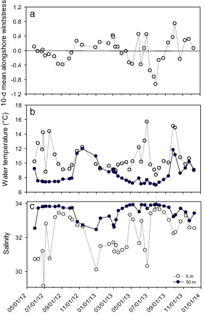

1. [Download: Download high-res image (330KB)](https://ars-els-cdn-com.reed.idm.oclc.org/content/image/1-s2.0-S007966111630252X-gr1_lrg.jpg)
2. [Download: Download full-size image](https://ars-els-cdn-com.reed.idm.oclc.org/content/image/1-s2.0-S007966111630252X-gr1.jpg)

Fig. 1. Time series of (a) mean alongshore wind stress at 44.6°N 124.1°W with values representing 10-d means prior to each sample date; (b) water temperature at 5 m (open circles) and 50 m (closed circles); and (c) salinity at 5 m and 50 m during sample collection at NH05.

### 3.2. Phytoplankton species, lipid, and FA composition

The phytoplankton species community analysis included 26 dates and 64 taxa that were present in at least 10% of the samples (Table S1). Eleven diatom taxa and Cryptophytes were numerically abundant with mean densities >14000 cells L<sup>−1</sup>. The remaining taxa had mean densities <9100 cells L<sup>−1</sup>. The majority of the variation in phytoplankton taxa (90.4%) was accounted for in a three-dimensional NMS solution (Axis 1 accounted for 64.4% of the variation, Axis 2 = 13.8%, and Axis 3 = 12.2%) (Fig. 2a). The stress for the final solution was 10.2 (instability = 0, 67 iterations).

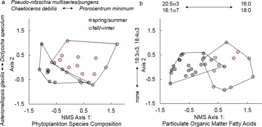

1. [Download: Download high-res image (245KB)](https://ars-els-cdn-com.reed.idm.oclc.org/content/image/1-s2.0-S007966111630252X-gr2_lrg.jpg)
2. [Download: Download full-size image](https://ars-els-cdn-com.reed.idm.oclc.org/content/image/1-s2.0-S007966111630252X-gr2.jpg)

Fig. 2. Nonmetric Multidimensional Scaling results for ordination of (a) 64 phytoplankton taxa and (b) 13 fatty acids (FAs) and a Bacterial Index (sum of 11 FAs) extracted from bulk water samples (particulate organic matter) collected at the same time. The species or FAs with the strongest, statistically significant correlations with each axis are included. Note that there were no FAs significantly, negatively correlated with Axis 2 (b). Each sample date was assigned to a season using cluster analysis. Spring/summer samples are blue circles and fall/winter samples red, stippled circles.

The densities of the several diatoms that were more abundant during summer months, including C*haetoceros debilis*, *C. lorenzianus*, *[Leptocylindrus](https://www-sciencedirect-com.reed.idm.oclc.org/topics/agricultural-and-biological-sciences/leptocylindrus)* *danicus*, *Pseudo-nitzschia multiseries/pungens*, and *[Skeletonema costatum](https://www-sciencedirect-com.reed.idm.oclc.org/topics/agricultural-and-biological-sciences/skeletonema-costatum)*, were negatively correlated with Axis 1 scores whereas densities of the dinoflagellate *[Prorocentrum](https://www-sciencedirect-com.reed.idm.oclc.org/topics/agricultural-and-biological-sciences/prorocentrum)* *minimum* were positively correlated with Axis 1 scores (Table 1). Densities of the some diatoms, including *Asterionellopsis glacialis*, *A. socialis*, *Ceratoneis* *closterium*, and the dinoflagellate *Protoperidinium bipes* were negatively correlated with Axis 2 scores (Table 1). The density of the silicoflagellate *Dictyocha speculum* was positively correlated with Axis 2 scores.

Table 1. Correlations between Axis 1 and 2 scores from the Nonmetric Multidimensional Scaling ordinations and phytoplankton taxa, particulate organic matter fatty acids, and physical variables. Only correlations that were significant after correction for multiple comparisons (*r* > 0.504) are included.

| Phytoplankton taxa | Axis 1 | Axis 2 | Physics | Axis 1 |
| --- | --- | --- | --- | --- |
| *Prorocentrum minimum* | 0.567 |  | Salinity @ 50 m | −0.770 |
| *Chaetoceros lorenzianus* | −0.606 |  | Water temp @ 50 m | 0.606 |
| *Leptocylindrus danicus* | −0.699 |  |  |  |
| *Skeletonema costatum* | −0.720 |  |  |  |
| *Pseudo-nitzschia multi/pungens* | −0.744 |  |  |  |
| *Chaetoceros debilis* | −0.789 |  |  |  |
| *Dictyocha speculum* |  | 0.664 |  |  |
| *Asterionellopsis glacialis* |  | −0.607 |  |  |
| *Ceratoneis closterium* |  | −0.611 |  |  |
| *Asterionellopsis socialis* |  | −0.547 |  |  |
| *Protoperidinium bipes* |  | −0.547 |  |  |
| Particulate organic matter fatty acids | Axis 1 | Axis 2 | Physics | Axis 1 |
| 16:2ω4 | −0.848 |  | Salinity @ 50 m | −0.703 |
| 16:1ω7 | −0.832 |  | Water temp @ 50 m | 0.751 |
| 16:4ω1 | −0.820 |  | 10-d mean alongshore wind stress | 0.733 |
| 14:0 | −0.820 |  |  |  |
| 20:5ω3 | −0.766 |  |  |  |
| 16:0 | 0.767 |  |  |  |
| 18:0 | 0.839 |  |  |  |
| 18:1ω9 | 0.571 |  |  |  |
| 18:1ω7 |  | 0.544 |  |  |
| 18:3ω3 |  | 0.641 |  |  |
| 18:4ω3 |  | 0.791 |  |  |

There was seasonal variation in the amount of total lipids within the particulate organic matter with the lowest values (0.01 mg L<sup>−1</sup>) occurring in three samples in late 2012 and early 2013 and the greatest values (0.12–0.17 mg L<sup>−1</sup>) occurring during summer of both years (Fig. 3). Polar lipids (66% ± 13) and free fatty acids (25% ± 10) were the largest contributors to the lipid pool. The percent contribution of sterols displayed the greatest variability (CV = 252%) whereas the contribution of polar lipids was the most stable (CV = 20%).

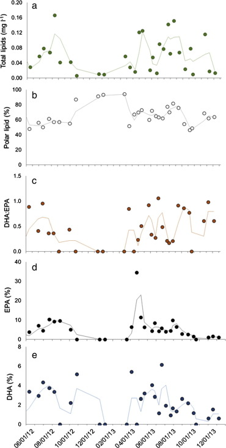

1. [Download: Download high-res image (163KB)](https://ars-els-cdn-com.reed.idm.oclc.org/content/image/1-s2.0-S007966111630252X-gr3_lrg.jpg)
2. [Download: Download full-size image](https://ars-els-cdn-com.reed.idm.oclc.org/content/image/1-s2.0-S007966111630252X-gr3.jpg)

Fig. 3. Time series of lipid parameters in [particulate organic matter](https://www-sciencedirect-com.reed.idm.oclc.org/topics/earth-and-planetary-sciences/particulate-organic-matter) collections from NH05 showing (a) total lipids (mg L<sup>–1</sup>); (b) polar lipids, expressed as percent of total lipids (%); (c) the DHA:EPA ratio; (d) EPA (%); and (e) DHA (%). The continuous lines represent two-point moving averages.

The particulate organic matter FA ordination included 34 dates and 13 FAs and the Bacterial Index (Table S2). One date (22 Oct 2013) was removed from the analysis as it was identified as an outlier (>3 standard deviations (SD) from the multivariate mean) due to very high levels of 16:0 and no 18:4ω3 or EPA or DHA. Four FAs each contributed an average of ≥10% of the total FAs present (Fig. 2b): myristic (14:0), palmitic (16:0), palmitoleic (16:1ω7), and stearic (18:0) acids. The majority of the variation in particulate organic matter FAs (95.3%) was also accounted for in a three-dimensional NMS solution (Axis 1 = 70.1%, Axis 2 = 12.2%, and Axis 3 = 13.0%) (Fig. 2b). The stress for the final solution was 8.0 (instability = 0, 60 iterations).

Five FAs, including diatom indicators 16:1ω7, hexadecatetraenoic acid (16:4ω1), and EPA (Budge and Parrish, 1999) as well as hexadecadienoic (16:2ω4), were negatively correlated with Axis 1 scores and were more common during summer months. In contrast, two ubiquitous FAs, 16:0 and 18:0, and [oleic acid](https://www-sciencedirect-com.reed.idm.oclc.org/topics/agricultural-and-biological-sciences/oleic-acid) (18:1ω9) were positively correlated with Axis 1 scores (Table 1). Three FAs, including vaccenic (18:1ω7), α-linolenic (18:3ω3), and stearidonic (18:4ω3) acids, were positively correlated with Axis 2 scores (Table 1).

We also evaluated the relationship between phytoplankton species composition and the particulate organic matter FAs and physical variables, including local alongshore and cross-shore wind stress and temperature (T) and salinity (S) at NH05 at 5 m and 50 m (Table 1). The variation in phytoplankton species composition was not significantly related to T or S at 5 m but was significantly related to T and S at 50 m. Communities dominated by diatoms occurred during periods with cooler, more saline waters that typically occur during the spring and summer upwelling season (negative x-axis values; Fig. 2a) whereas communities with fewer diatoms were present during warmer periods that typically occur during fall and winter months (positive x-axis values; Fig. 2a). Similar relationships with [water salinity](https://www-sciencedirect-com.reed.idm.oclc.org/topics/earth-and-planetary-sciences/water-salinity) and temperature at 50 m were observed for the particulate organic matter FAs.

The variability in particulate organic matter FAs was significantly and positively correlated with the variability in phytoplankton species composition (correlation between Axis 1 scores from FA and species ordinations presented in Fig. 2: *r* = 0.602, *n* = 24). Overall, negative Axis 1 scores were observed primarily during spring and summer and were associated with cooler, more saline waters, higher densities and diversity of diatoms, and a greater contribution of FAs associated with diatoms (16:1ω7, 16:4ω1, and EPA) as well as 18:3ω3 and 18:4ω3. Positive Axis 1 scores were observed primarily during fall and winter and were associated with warmer, less saline waters, reduced species richness, and a greater contribution of 16:0, 18:0, and 18:1ω9.

### 3.3. Copepod species, lipid, and FA composition

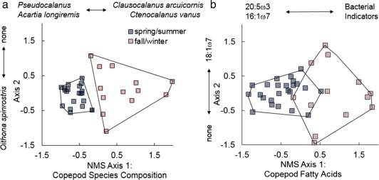

1. [Download: Download high-res image (147KB)](https://ars-els-cdn-com.reed.idm.oclc.org/content/image/1-s2.0-S007966111630252X-gr4_lrg.jpg)
2. [Download: Download full-size image](https://ars-els-cdn-com.reed.idm.oclc.org/content/image/1-s2.0-S007966111630252X-gr4.jpg)

Fig. 4. Nonmetric Multidimensional Scaling results for ordination of (a) 25 copepod taxa and (b) 11 fatty acids (FAs) and a Bacterial Index (sum of 11 FAs) extracted from samples collected at the same time. The species or FAs with the strongest correlations with each axis are included. Note that there were no species significantly, positively correlated with Axis 2 (a) and no FAs significantly, negatively correlated with Axis 2 (b). Each sample date was assigned to a season using cluster analysis. Spring/summer samples are blue squares and fall/winter samples are red, stippled squares.

Table 2. Correlations between Axis 1 scores from the Nonmetric Multidimensional Scaling ordinations of the copepod taxa, fatty acids, and physical variables. Only correlations that are significant after correction for multiple comparisons (*r* > 0.470) are included.

| Copepod taxa | Axis 1 | Axis 2 | Physics | Axis 1 |
| --- | --- | --- | --- | --- |
| *Clausocalanus arcuicornis* | 0.921 |  | Water temp @ 50 m | 0.704 |
| *Ctenocalanus vanus* | 0.889 |  | Salinity @ 50 m | −0.772 |
| *Clausocalanus pergens* | 0.869 |  |  |  |
| *Acartia danae* | 0.811 |  |  |  |
| *Mesocalanlus tenuicornis* | 0.781 |  |  |  |
| *Calanus pacificus* | 0.754 |  |  |  |
| *Corycaeus anglicus* | 0.706 |  |  |  |
| *Clausocalanus pergens* | 0.702 |  |  |  |
| *Calocalanus tenuis* | 0.696 |  |  |  |
| *Centropages abdominalis* | −0.731 |  |  |  |
| *Acartia hudsonica* | −0.743 |  |  |  |
| *Acartia longiremis* | −0.751 |  |  |  |
| *Pseudocalanus* | −0.851 |  |  |  |
| *Oithona spinirostris* |  | −0.637 |  |  |
| Copepod fatty acids | Axis 1 | Axis 2 | Physics | Axis 1 |
| Bacterial Index | 0.848 |  | Water temp @ 50 m | 0.643 |
| 18:0 | 0.797 |  | Salinity @ 50 m | −0.707 |
| 16:0 | 0.707 |  |  |  |
| 14:0 | 0.731 |  |  |  |
| 22:6ω3 | 0.471 |  |  |  |
| 18:4ω3 | 0.477 |  |  |  |
| 18:1ω9 | −0.545 |  |  |  |
| 16:4ω1 | −0.672 |  |  |  |
| 16:1ω7 | −0.767 |  |  |  |
| 20:5ω3 | −0.806 |  |  |  |
| 18:1ω7 |  | 0.614 |  |  |

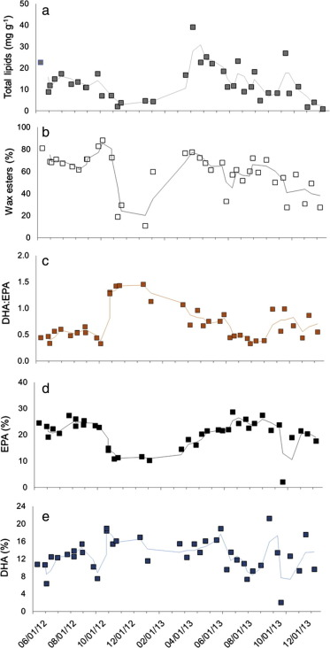

1. [Download: Download high-res image (142KB)](https://ars-els-cdn-com.reed.idm.oclc.org/content/image/1-s2.0-S007966111630252X-gr5_lrg.jpg)
2. [Download: Download full-size image](https://ars-els-cdn-com.reed.idm.oclc.org/content/image/1-s2.0-S007966111630252X-gr5.jpg)

Fig. 5. Time series of lipid parameters from copepod collections at NH05 highlighting (a) total lipids per WW (mg g<sup>−1</sup>); (b) [wax esters](https://www-sciencedirect-com.reed.idm.oclc.org/topics/agricultural-and-biological-sciences/wax-ester) (% of total lipids); (c) the DHA:EPA ratio; (d) EPA (%); and (d) DHA (%). The continuous lines represents two-point moving averages.

The final ordination of copepod FAs included 33 dates and 11 FAs and the Bacterial Index (Table S4). Two dates (23 Jul 2013 and 04 Oct 2013) were identified as outliers (>3 SD from the mean) and removed from the analysis (Table S4). The majority of the variation in copepod FAs (85.6%) was accounted for in a two-dimensional NMS solution (Axis 1 = 69.7% and Axis 2 = 15.9%) (Fig. 4b). The stress for the final solution was 17 (instability = 0, 84 iterations).

Four FAs each contributed >10% of the total: 14:0, 16:0, EPA, and DHA. Four FAs indicative of diatom production, 16:1ω7, 16:4ω1, 16:2ω4, and EPA, were negatively correlated with Axis 1 scores (Table 2). The Bacterial Index was strongly, positively correlated with Axis 1 scores (Table 2) along with 14:0, 16:0 and 18:0. The only correlation with Axis 2 was a positive relationship between 18:1ω7 and Axis 2 scores.

Similar to our analysis of the phytoplankton, we evaluated the relationship between the copepod species and FA composition and key physical variables (Table 2). The copepod species composition was significantly correlated with T and S at 50 m: communities dominated by northern copepod species, such as *Pseudocalanus* and *Acartia*, occurred during more saline and cooler conditions (upwelling). Similarly, copepod FAs indicative of diatom production (20:5ω3 and 16:1ω7) were more abundant during cooler, more saline conditions whereas the Bacterial Index and 14:0, 16:0, and 18:0 were more abundant during warmer, less saline conditions that typically occurred during fall and winter.

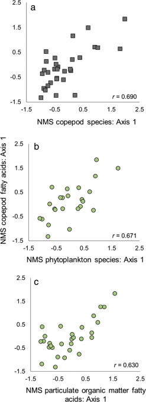

1. [Download: Download high-res image (124KB)](https://ars-els-cdn-com.reed.idm.oclc.org/content/image/1-s2.0-S007966111630252X-gr6_lrg.jpg)
2. [Download: Download full-size image](https://ars-els-cdn-com.reed.idm.oclc.org/content/image/1-s2.0-S007966111630252X-gr6.jpg)

Fig. 6. Relationship between the Axis 1 scores from the Nonmetric Multidimensional Scaling (NMS) analysis of the copepod fatty acids and the Axis 1 scores from the NMS analysis of (a) copepod species composition, (b) phytoplankton species composition, and (c) particulate organic matter fatty acid composition.

### 3.4. Seasonal transitions

There were clear seasonal transitions identified within the phytoplankton and copepod species and FA datasets. Seasons delineated using cluster analysis aligned with sign changes in the Axis 1 scores of their respective ordinations, and there was strong support for the seasonal clusters identified in all six data sets (MRPP, *p* < 0.0001). Overall, our time series included two fall transitions (2012 and 2013) and one spring transition (2013) (Table 3). Seasonal shifts in the phytoplankton species composition were detected within one week of the physical indicators during fall and within three to four weeks of the physical transition during spring. The seasonal shift in particulate organic matter FAs was coincident with the phytoplankton species community shift during the fall transitions (2012 and 2013) but preceded the phytoplankton community shift by more than four weeks during the spring transition.

Table 3. Seasonal transitions based on physical, biological, and biochemical indicators. “ND” indicates that no clear transition was detectable in the data series. Bold highlights seasonal shifts that occurred on the same sample day as shifts in copepod fatty acid composition. See text for additional details on metrics and method used to delineate seasons.

| Empty Cell | 2012 Fall transition | 2013 Spring transition | 2013 Fall transition |
| --- | --- | --- | --- |
| *Physical metrics* |  |  |  |
| Upwelling 10-d mean | 11 Oct | 6 Apr | 18 Sep |
| Alongshore wind stress | 10 Oct | 11 Apr | 15 Sep |
| *Phytoplankton metrics* |  |  |  |
| Phytoplankton species composition | 7 Oct | 8 May | **11 Sep** |
| Particulate organic matter fatty acids | 7 Oct | **1 Apr** | **11 Sep** |
| Diatom:Dinoflagellate ratio | **25 Oct** | **1 Apr** | ND |
| *Copepod metrics* |  |  |  |
| Copepod species composition | 7 Oct | 18 Mar | 26 Sep |
| Copepod fatty acids | **25 Oct** | **1 Apr** | **11 Sep** |

The seasonal shifts in the copepod species composition occurred within 3–12 d of the physical transition during fall 2012 and 2013. Additionally, the copepod species transition occurred at the same time as the phytoplankton species transition during fall 2012 (7 Oct). However, in spring 2013, a clear shift in the copepod community was detected > 10 d earlier than the physical transition and six weeks prior to a shift in the phytoplankton species composition (Table 3). The earlier community transition appeared to be due to an increased number and biomass of *Calanus marshallae* and declines in southern copepod species. During fall 2013, the copepod community shift was detected after the physical transition and one sample after the seasonal shift in phytoplankton community composition. During each transition, shifts in the copepod FAs were consistently offset from shifts in the copepod species composition by approximately two weeks (1–2 sample dates) but were always coincident with transitions in particulate organic matter FAs or the Diatom:Dinoflagellate ratio.

Finally, we examined lipid classes, total lipids, biomass estimates, the DHA:EPA ratio, and the Bacterial Index between seasons. Given the differences in the dates of the seasonal delineations based on phytoplankton versus copepod species composition (see Table 3), we compared seasons separately for each group to evaluate differences in food web quality (Table 4). For phytoplankton, total lipids were approximately 2x greater and biomass was approximately 5x greater during spring/summer compared with fall/winter. The percent contribution of sterols and the Bacterial Index were also greater in spring/summer compared with fall/winter. Phytoplankton DHA:EPA did not vary between seasons primarily due to consistently low or, in the winter, occasionally undetectable levels of DHA. On average, EPA contributed 8% of the particulate organic matter FA pool during summer and 1% during winter. For copepods, total lipids were also approximately 2x greater and biomass was approximately 5x greater during spring/summer compared with fall/winter. Additionally, the percent contribution of wax esters were greater in spring/summer and the percent contribution of sterols, polar lipids, DHA:EPA, and the Bacterial Index were greater in fall/winter. The seasonal difference in copepod DHA:EPA was due to variation in EPA (23.1% contribution in summer vs. 16.5% in winter) as DHA did not significantly vary between seasons (12.8% in summer vs. 13.0% in winter). Although the proportional contribution of bacteria in the copepod community was greater in the winter, the concentrations were similar (mean = 0.27 mg g<sup>−1</sup> in summer and in winter), highlighting the seasonal shift in the relative importance of bacterial production for copepods during periods of lower productivity.

Table 4. Seasonal means (±1 SE) for the percent contribution of lipid classes, including wax esters (WE), [triacylglycerols](https://www-sciencedirect-com.reed.idm.oclc.org/topics/agricultural-and-biological-sciences/triglyceride) (TAG), sterols (ST), and polar lipids (PL), amount of total lipid, biomass estimates, DHA:EPA, and the percent contribution of the Bacterial Index, which is the sum of *i*15:0, *αi*15:0, 15:0, 15:1, *i*16:0, *αi*16:0, *i*17:0, *αi*17:0, 17:0, 17:1, and 18:1ω6, to total lipids. Seasons were determined based on cluster analysis of phytoplankton and copepod species composition (see Table 3). Total lipids are reported in mg L<sup>−1</sup> for phytoplankton and mg g<sup>−1</sup> for copepods. Biomass is presented as mg m<sup>−3</sup> for both phytoplankton and copepods. Significant differences between seasons are indicated by an “*” (*p* < 0.02).

| Season | %WE | %TAG | %ST | %PL | TL | Biomass | DHA:EPA | Bacterial Index |
| --- | --- | --- | --- | --- | --- | --- | --- | --- |
| *Phytoplankton species composition* |  |  |  |  |  |  |  |  |
| Sp/Su | 1.7 (3.5) | 4.3 (5.2) | 5.2 (2.9)* | 64.4 (9.8) | 0.08 (0.01)* | 520 (53)* | 0.49 (0.33) | 7.1 (2.1)* |
| Fa/W | 1.8 (0.5) | 2.1 (4.0) | 2.2 (3.1) | 68.7 (16.6) | 0.04 (0.01) | 102 (26) | 0.38 (0.39) | 4.8 (1.9) |
| *Copepod species composition* |  |  |  |  |  |  |  |  |
| Sp/Su | 65.7 (2.2)* | 5.6 (0.4) | 2.8 (0.4)* | 18.4 (1.5)* | 15.9 (1.5)* | 23.3 (2.0)* | 0.59 (0.19)* | 1.8 (0.4)* |
| Fa/W | 45.2 (7.2) | 8.0 (1.5) | 5.0 (0.8) | 30.9 (6.5) | 7.2 (2.2) | 5.2 (0.5) | 0.88 (0.39) | 3.6 (1.2) |

## 4. Discussion

Our primary intent was to quantify the temporal variation in the lipid class and FA composition of the coastal copepod community within the Northern California Current and to determine the relative importance of species versus diet composition in the regulation of copepod lipid quantity and quality. Copepods are the primary link between primary producers and higher trophic levels even though they display plasticity in feeding mode ranging from carnivory to omnivory and herbivory (El-Sabaawi et al., 2009a; Connelly et al., 2016). Therefore, it was also important to track and examine temporal variation in the phytoplankton species composition and lipid composition of the particulate organic matter. We observed a high level of covariation between species composition and biochemistry within and across trophic levels and there were distinct seasonal patterns. However, shifts in the copepod species community based on both density and biomass estimates were consistently offset from shifts in their FA composition, which more directly reflected shifts in the species composition of primary producers and the biochemistry of the particulate organic matter. Although these findings are based on collections at one oceanographic station (NH05), there are some data that indicate copepod community composition is spatially coherent, at least from central Oregon to northern Washington during summer months (Lamb, 2011). However, additional data across broader spatial scales are needed to more fully describe seasonal variation in copepod nutritional quality. These results highlight the need to consider species composition, diet, reproductive state, and the timing of seasonal transitions in species and FA composition when evaluating factors regulating the variation in copepod nutritional quality as prey.

Variation in the timing of seasonal transitions as identified with the physical, biological, and biochemical indicators provides some insight into the processes regulating lipid quantity and quality of lower trophic levels. The physical data used to identify transition dates were available at a higher temporal frequency (daily) than the species and biochemical data, which were collected approximately every two weeks. Therefore, evaluations across indicators must take this into consideration. However, it is noteworthy that our indicator of particulate organic matter FA composition (Axis 1 scores) consistently displayed seasonal transitions within 5 d of the physical indicators (upwelling or alongshore wind stress). Seasonal transitions in day length, solar irradiance, and nutrient availability influence phytoplankton growth cycles and the FA composition of the community (Mayzaud et al., 1990, Galloway and Winder, 2015). Thus these factors may have contributed to the observed shifts in particulate organic matter FAs shortly before or at the same time as reversals in the dominant wind patterns and large-scale [water mass](https://www-sciencedirect-com.reed.idm.oclc.org/topics/earth-and-planetary-sciences/water-mass) exchanges associated with physical seasonal transitions.

There were however some notable offsets between seasonal shifts in the phytoplankton species and the FA composition of the particulate organic matter. In fall 2012, the phytoplankton species and FA composition both transitioned on 7 Oct but the Diatom:Dinoflagellate ratio remained relatively high until the next sample on 25 Oct, which is also when the copepod FAs transitioned. Although two FAs shifted in relative importance on 7 Oct, certain diatom species that were abundant during summer, including *[Chaetoceros](https://www-sciencedirect-com.reed.idm.oclc.org/topics/agricultural-and-biological-sciences/chaetoceros)* *socialis* and *[Nitzschia](https://www-sciencedirect-com.reed.idm.oclc.org/topics/agricultural-and-biological-sciences/nitzschia)* spp., were still present at >10000 cells L<sup>−1</sup> until 25 Oct. Further, in spring 2013, particulate organic matter FAs shifted over a month earlier than the phytoplankton species composition, and copepod FAs transitioned at the same time as the particulate organic matter FAs. A marked increase in diatom FAs occurred on 1 Apr and the Diatom:Dinoflagellate ratio also shifted to summer conditions on 1 Apr but remained relatively low for several samples. However, it was not until 8 May that several species of diatoms, including *Chaetoceros* spp. and *Pseudo-nitchiza* spp., increased from 0 to 1000 s of cells L<sup>−1</sup>, contributing to the seasonal shift in the species community composition. In fall 2013, the phytoplankton species and particulate organic matter FAs were again coherent and both transitioned on 11 Sep as did the copepod FAs. Although there were notable declines in several species of diatom, including *Chaetoceros* spp., *Asterionellopsis* spp., on 11 Sep, there were “blooms” of several diatoms (>20,000 cells L<sup>−1</sup>) including *Asterionellopsis* sp., *Nitzchia* spp., *Chaetoceros* spp., *[Thalassionema](https://www-sciencedirect-com.reed.idm.oclc.org/topics/agricultural-and-biological-sciences/thalassionema)* sp., and *[Thalassiosira](https://www-sciencedirect-com.reed.idm.oclc.org/topics/agricultural-and-biological-sciences/thalassiosira)* sp. until 9 Dec, and the Diatom:Dinoflagellate ratio never displayed a clear fall transition. Overall, seasonal transitions in the copepod community FAs were coincident with shifts in the Diatom:Dinoflagellate ratio for two of the three transitions, which, perhaps not surprisingly, indicates that the relative abundance of diatoms can be good proxy for shifts in copepod community FAs.

The pattern of seasonal transitions identified based on the copepod species community and copepod FA composition was also informative. Although our time series includes only three transitions, the copepod species community never transitioned at the same time as the copepod FA composition but they did transition within two weeks of each other. Furthermore, the shifts in copepod FAs were consistently detected at the same time as shifts in the particulate organic matter FA or Diatom:Dinoflagellate ratio, with no lag. One expectation is that, if species community transitions are primarily related to a physically-driven, large-scale water transport, shifts across taxonomic groups and indices would be relatively coherent. An alternate expectation is that the coastal copepod community is influenced by mixing of different source waters as well as copepod behavior (Peterson et al., 1979), reproductive state, and growth rates: hence, it could take some time for the copepod species composition to reflect physical seasonal transitions and potentially even longer for their FAs to shift due to the time needed for tissue turnover and FA incorporation (Dalsgaard et al., 2003, De Troch et al., 2012). We observed some evidence in support of both of these expectations. In fall 2012 the copepod species community transition was coherent with the physical and phytoplankton species and FA indicators but the copepod FA shift was not apparent until the next sample date, which coincided with shifts in the Diatom:Dinoflagellate ratio. In spring 2013, the copepod community composition once again transitioned earlier than the copepod FAs, which shifted at the same time as the particulate organic matter FAs. However, in fall 2013, the copepod species composition did not shift until after the copepod FA compositional shift, which occurred at the same time as transitions in phytoplankton species, particulate organic matter FA composition, and the Diatom:Dinoflagellate ratio. Hence, based on our observations, it appears that the FA composition of the copepod community more closely reflects the phytoplankton species composition and FA composition of particulate organic matter than the species composition of the copepods.

The variable patterns observed across seasons and indicators may be due, at least in part, to differences in the character of each transition. Fall transitions bring offshore waters to the coast as downwelling begins whereas spring transitions lead to upwelling, offshore transport, and the mixing of waters recently brought to the surface with more northern waters. The fall 2012 transition was quite distinct with a clear shift in winds and minimal variability in [wind direction](https://www-sciencedirect-com.reed.idm.oclc.org/topics/agricultural-and-biological-sciences/wind-direction) compared with the fall 2013 transition, which was characterized by highly variable winds that persisted until the end of our sampling. Hence the copepod community would be expected to take longer to stabilize in the fall of 2013 than 2012, and this is what we observed: the density of three northern species (*Pseudocalanus* *mimus*, *[Acartia](https://www-sciencedirect-com.reed.idm.oclc.org/topics/agricultural-and-biological-sciences/acartia)* *longiremis*, and *[Calanus](https://www-sciencedirect-com.reed.idm.oclc.org/topics/agricultural-and-biological-sciences/calanus)* *marshallae*) remained high through fall of 2013. Given that we only have one spring transition, additional data are needed to determine if shifts in the copepod community consistently lead shifts in the phytoplankton community. Additionally, it is worth noting that the removal of three multivariate outliers (23 Jul 13 and 4 Oct 13 for copepod FAs and 22 Oct 13 for particulate organic matter) did not influence the seasonal designations.

The dominance of FA markers indicative of diatom production within copepods during summer would be expected within a seasonal upwelling region, such as the Northern California Current. A greater proportion of bacterial FAs within copepods during fall and winter would also be anticipated if copepods were more reliant on bacterial production during periods of low primary productivity, i.e., consume heterotrophic organisms. Small dinoflagellates and small and large ciliates were proportionally more abundant during fall and winter based on biomass estimate: consumption of these groups by copepods could result in a proportional increase in copepod bacterial FAs if those groups were more reliant on bacteria during fall and winter. However, the doubling of bacterial FA percent contribution to the copepod community in the winter compared with summer resulted in similar concentrations of bacterial FAs within the copepod community due to lower lipid levels during winter. Thus, an alternative explanation could be catabolism of non-bacterial FAs during periods of low food availability, which would increase the relative contribution of bacterial FAs remaining (Mayor et al., 2011, Mayor et al., 2015). The contrasting decline in bacterial FAs measured within particulate organic matter during fall and winter (1.9 µg L<sup>−1</sup>) compared with summer (5.7 µg L<sup>−1</sup>) could be due, in part, to the overall low productivity and low lipid levels during fall and winter. However, the standing stock of bacteria reflects both production and grazing, and we have no means to differentiate their relative importance in this study.

In this study, we focused on community-level differences. However, we collected individuals, when possible, to help separate the influence of species-specific variation and dietary influences in regulating lipid content and composition. *Calanus marshallae* is a large-bodied, boreal copepod species that is common during spring and summer upwelling but can be collected throughout much of the year. During our study, *C. marshallae* dry weight averaged 284.4 µg ± 54.8 SD, ranging from 163 to 428 µg, and we observed extensive variation in the total lipid within *C. marshallae* adults, ranging from 39 to 299 µg ind<sup>−1</sup>. Additionally, the contribution of EPA to the total FA pool of *C. marshallae* ranged from 7% to 25%, which was similar to the range observed for all of the bulk copepod samples (10–29%). These data demonstrate substantial variation at the species level, which, whether due to changes in condition related to diapause, reproduction, prey variation, or other factors, can be considerable and have effects on the quality of copepods as prey. Additional information on species-specific variation in lipid quantity and composition at lower trophic levels will be needed to further quantify the relative importance of species versus prey in regulating the nutritional quality of secondary consumers.

In conclusion, this study advances our understanding of the temporal variation in the lipid quantity and quality of phytoplankton and copepods in the Northern California Current and is an important step in determining the degree to which enhanced growth and survival of higher trophic levels are influenced by the taxonomic composition and nutritional quality of their prey. Overall, in addition to greater biomass, the amount of total lipid present in particulate organic matter and the copepod community was twice as high in the spring and summer, and there was clear seasonal variation in the FA composition. For the copepod community, this was primarily due to large increases in wax esters and higher levels of EPA during summer than winter, which could support greater productivity in higher trophic levels. The seasonal differences in the lipid and FA composition of the copepod community were strongly correlated with the copepod species composition as well as the species and FA composition of the phytoplankton. However, the timing of seasonal shifts in copepod FAs reflected shifts in the phytoplankton species and FA composition more than the copepod species community. This synchrony highlights the importance of interactions between the copepod community and available prey in regulating the nutritional quality of copepods.

## Acknowledgements

Funding was provided by grants from NOAA Living Marine Resources Cooperative Science Center (TAB 14-05) to JAM and NOAA Fisheries and the Environment Program and NSF Comparative Analysis of Marine Ecosystem Organization to WTP. Invaluable field and laboratory assistance was provided by J. Fisher, J. Lamb, X. Hermosillo, J. Peterson, K. Klinck, A. Sremba, L. Perry, and J. Porquez. Helpful comments were provided by several anonymous reviewers.

## Appendix A. Supplementary material

[Download: Download Word document (36KB)](https://ars-els-cdn-com.reed.idm.oclc.org/content/image/1-s2.0-S007966111630252X-mmc1.docx)

Supplementary data 1.

## References

1. Batten et al., 2016

   S.D. Batten, S. Moffitt, W.S. Pegau, R. Campbell

   Plankton indices explain interannual variability in Prince William Sound herring first year growth

   Fish. Ocean., 25 (2016), pp. 420-432, 10.1111/fog.12162

   View at publisher

   [View in Scopus](https://www.scopus.com/inward/record.url?eid=2-s2.0-84976615712&partnerID=10&rel=R3.0.0)Google Scholar
2. Beamish and Noakes, 2002

   Beamish, R.J., Noakes, D.J., 2002. The role of climate in the past, present, and future of Pacific salmon fisheries off the west coast of Canada. In: McGinn, N.A. (Ed.), Fisheries in a Changing Climate. Am. Fish. Soc. Symp. vol. 32, pp. 231–244. doi: [http://dx.doi.org.reed.idm.oclc.org/10.1029/2011GL047927](https://doi.org/10.1029/2011GL047927).

   Google Scholar
3. Bi et al., 2011

   H.S. Bi, W.T. Peterson, P.T. Strub

   Transport and coastal zooplankton communities in the northern California current system

   Geophys. Res. Lett., 38 (2011), 10.1029/2011GL047927

   [View at publisher](https://ct.prod.getft.io/c2NpZW5jZWRpcmVjdF9jb250ZW50aG9zdGluZyx3aWxleSxodHRwOi8vd3d3LmFndS5vcmcvam91cm5hbHMvZ2wvZ2wxMTEyLzIwMTFHTDA0NzkyNy8yMDExR0wwNDc5MjcucGRm.wPc_tnpxCNbLMg6yIBBuAb8mmISFldF4_O4oXCzJkJ4)

   Google Scholar
4. Botsford, 2001

   L.W. Botsford

   Physical influences on recruitment to California current invertebrate populations on multiple scales

   ICES J. Mar. Res., 58 (2001), pp. 1081-1091, 10.1006/jmsc.2001.1085

   View at publisher

   [View in Scopus](https://www.scopus.com/inward/record.url?eid=2-s2.0-0034768720&partnerID=10&rel=R3.0.0)Google Scholar
5. Brett and Muller-Navarra, 1997

   M.T. Brett, D.C. Muller-Navarra

   The role of highly unsaturated fatty acids in aquatic food web processes

   Fresh. Biol., 38 (1997), pp. 483-499, 10.1046/j.1365-2427.1997.00220.x

   View at publisher

   [View in Scopus](https://www.scopus.com/inward/record.url?eid=2-s2.0-2642702566&partnerID=10&rel=R3.0.0)Google Scholar
6. Budge and Parrish, 1998

   S.M. Budge, C.C. Parrish

   Lipid biogeochemistry of plankton, settling matter and sediments in Trinity Bay, Newfoundland. II. Fatty acids

   Org. Geochem., 29 (1998), pp. 1547-1559, 10.1016/S0146-6380(98)00177-6

   [View PDF](https://www-sciencedirect-com.reed.idm.oclc.org/science/article/pii/S0146638098001776/pdfft?md5=6bc5ab9654d0ae4c513fed8cc159cd24&pid=1-s2.0-S0146638098001776-main.pdf)[View article](https://www-sciencedirect-com.reed.idm.oclc.org/science/article/pii/S0146638098001776)[View in Scopus](https://www.scopus.com/inward/record.url?eid=2-s2.0-0032215790&partnerID=10&rel=R3.0.0)Google Scholar
7. Budge and Parrish, 1999

   S.M. Budge, C.C. Parrish

   Lipid class and fatty acid composition of *Pseudo-nitzschia multiseries* and *Pseudo-nitzschia pungens* and effects of lipolytic enzyme deactivation

   Phytochemistry, 52 (1999), pp. 561-566, 10.1016/S0031-9422(99)00241-1

   [View PDF](https://www-sciencedirect-com.reed.idm.oclc.org/science/article/pii/S0031942299002411/pdfft?md5=c982850e7965b5e389dbf603af07df35&pid=1-s2.0-S0031942299002411-main.pdf)[View article](https://www-sciencedirect-com.reed.idm.oclc.org/science/article/pii/S0031942299002411)[View in Scopus](https://www.scopus.com/inward/record.url?eid=2-s2.0-0032726515&partnerID=10&rel=R3.0.0)Google Scholar
8. Budge et al., 2006

   S.M. Budge, S.J. Iverson, H.N. Koopman

   Studying trophic ecology in marine ecosystems using fatty acids: A primer on analysis and interpretation

   Mar. Mammal Sci., 22 (2006), pp. 759-801, 10.1111/j.1748-7692.2006.00079.x

   View at publisher

   [View in Scopus](https://www.scopus.com/inward/record.url?eid=2-s2.0-33748930236&partnerID=10&rel=R3.0.0)Google Scholar
9. Budge et al., 2014

   S.M. Budge, E. Devred, M.H. Forget, V. Stuart, M.K. Trzcinski, S. Sathyendranath, T. Platt

   Estimating concentrations of essential omega-3 fatty acids in the ocean: supply and demand

   ICES J. Mar. Res., 71 (2014), pp. 1885-1893, 10.1371/journal.pone.0054134

   View at publisher

   [View in Scopus](https://www.scopus.com/inward/record.url?eid=2-s2.0-84911363081&partnerID=10&rel=R3.0.0)Google Scholar
10. Burke et al., 2013

    B.J. Burke, W.T. Peterson, B.R. Beckman, C. Morgan, E.A. Daly, M. Litz

    Multivariate models of adult Pacific salmon returns

    PLoS One, 8 (2013), 10.1371/journal.pone.0054134

    [View at publisher](https://doi.org/10.1371/journal.pone.0054134)Google Scholar
11. Connelly et al., 2016

    T.L. Connelly, T.N. Businski, D. Deibel, C.C. Parrish, P. Trela

    Annual cycle of lipid content and lipid class composition in zooplankton from the Beaufort Sea shelf, Canadian Arctic

    Can. J. Fish. Aquat. Sci., 73 (2016), pp. 747-758, 10.1139/cjfas-2015-0333

    [View at publisher](https://doi.org/10.1139/cjfas-2015-0333)[View in Scopus](https://www.scopus.com/inward/record.url?eid=2-s2.0-84989236130&partnerID=10&rel=R3.0.0)Google Scholar
12. Copeman and Laurel, 2010

    L.A. Copeman, B.J. Laurel

    Experimental evidence of fatty acid limited growth and survival in Pacific cod larvae

    Mar. Ecol. Prog. Ser., 412 (2010), pp. 259-272, 10.3354/meps08661

    [View at publisher](https://doi.org/10.3354/meps08661)[View in Scopus](https://www.scopus.com/inward/record.url?eid=2-s2.0-77955971966&partnerID=10&rel=R3.0.0)Google Scholar
13. Copeman et al., 2002

    L.A. Copeman, C.C. Parrish, J.A. Brown, M. Harel

    Effects of docosahexaenoic, eicosapentaenoic, and arachidonic acids on the early growth, survival, lipid composition and pigmentation of yellowtail flounder (*Limanda ferruginea*): a live food enrichment experiment

    Aquaculture, 210 (2002), pp. 285-304, 10.1016/S0044-8486(01)00849-3

    [View PDF](https://www-sciencedirect-com.reed.idm.oclc.org/science/article/pii/S0044848601008493/pdfft?md5=10a1b3b157c3b89b914de6814bc14bc7&pid=1-s2.0-S0044848601008493-main.pdf)[View article](https://www-sciencedirect-com.reed.idm.oclc.org/science/article/pii/S0044848601008493)[View in Scopus](https://www.scopus.com/inward/record.url?eid=2-s2.0-0037205840&partnerID=10&rel=R3.0.0)Google Scholar
14. Copeman et al., 2016

    L.A. Copeman, B.J. Laurel, A. Sremba, K. Klinck, R. Heintz, J. Vollenweider, K. Boswell

    Ontogenetic variability in the lipid content of saffron Cod (*Eleginus gracilis*) from the Western Arctic and Northern Chukchi

    Polar Biol., 39 (6) (2016), pp. 1109-1126, 10.1007/s00300-015-1792-y

    [View at publisher](https://ct.prod.getft.io/c2NpZW5jZWRpcmVjdF9jb250ZW50aG9zdGluZyxzcHJpbmdlcixodHRwOi8vbGluay5zcHJpbmdlci5jb20vY29udGVudC9wZGYvMTAuMTAwNy9zMDAzMDAtMDE1LTE3OTIteS5wZGY.9giOqnaNtJlRTjjHafwXkIVckjjWjWKsGkuNw64c7GA)

    [View in Scopus](https://www.scopus.com/inward/record.url?eid=2-s2.0-84944617147&partnerID=10&rel=R3.0.0)Google Scholar
15. Dalsgaard et al., 2003

    J. Dalsgaard, M. St. John, G. Kattner, D. Müller-Navarra, W. Hagen

    Fatty acid trophic markers in the pelagic marine environment

    Adv. Mar. Biol., 46 (2003), pp. 225-340, 10.1016/S0065-2881(03)46005-7

    [View PDF](https://www-sciencedirect-com.reed.idm.oclc.org/science/article/pii/S0065288103460057/pdf?md5=f0d19f39dfd958e4849197736ab0eb9a&pid=1-s2.0-S0065288103460057-main.pdf)[View article](https://www-sciencedirect-com.reed.idm.oclc.org/science/article/pii/S0065288103460057)[View in Scopus](https://www.scopus.com/inward/record.url?eid=2-s2.0-0642278103&partnerID=10&rel=R3.0.0)Google Scholar
16. De Troch et al., 2012

    M. De Troch, P. Boeckx, C. Cnudde, D. Van Gansbeke, A. Vanreusel, M. Vincx, M.J. Caramujo

    Bioconversion of fatty acids at the basis of marine food webs: insights from a compound-specific stable isotope analysis

    Mar. Ecol. Prog. Ser., 465 (2012), pp. 53-67, 10.3354/meps09920

    [View at publisher](https://doi.org/10.3354/meps09920)[View in Scopus](https://www.scopus.com/inward/record.url?eid=2-s2.0-84866974596&partnerID=10&rel=R3.0.0)Google Scholar
17. Du and Peterson, 2014a

    X.N. Du, W.T. Peterson

    Seasonal cycle of phytoplankton community composition in the coastal upwelling system off central Oregon in 2009

    Estuar. Coast., 37 (2014), pp. 299-311, 10.1007/s12237-013-9679-z

    [View at publisher](https://ct.prod.getft.io/c2NpZW5jZWRpcmVjdF9jb250ZW50aG9zdGluZyxzcHJpbmdlcixodHRwOi8vbGluay5zcHJpbmdlci5jb20vY29udGVudC9wZGYvMTAuMTAwNy9zMTIyMzctMDEzLTk2Nzktei5wZGY.KjudikZYcz3QVA_x2bn3f0oGSxFkml31KCLj96iSNX8)

    [View in Scopus](https://www.scopus.com/inward/record.url?eid=2-s2.0-84898057748&partnerID=10&rel=R3.0.0)Google Scholar
18. Du and Peterson, 2014b

    X.N. Du, W.T. Peterson

    Feeding rates and selectivity of adult *Euphausia pacifica* on natural particle assemblages in the coastal upwelling zone off Oregon, USA

    J. Plank. Res., 36 (2014), pp. 1031-1046, 10.1093/plankt/fbu027

    View at publisher

    [View in Scopus](https://www.scopus.com/inward/record.url?eid=2-s2.0-84904358116&partnerID=10&rel=R3.0.0)Google Scholar
19. Du et al., 2015

    X.N. Du, W.T. Peterson, L. O'Higgins

    Interannual variations in phytoplankton community structure in the northern California Current during the upwelling seasons of 2001–2010

    Mar. Ecol. Prog. Ser., 519 (2015), pp. 75-87, 10.3354/meps1109

    [View at publisher](https://doi.org/10.3354/meps11097)[View in Scopus](https://www.scopus.com/inward/record.url?eid=2-s2.0-84921913501&partnerID=10&rel=R3.0.0)Google Scholar
20. El-Sabaawi et al., 2009a

    R. El-Sabaawi, J.F. Dower, M. Kainz, A. Mazumder

    Characterizing dietary variability and trophic positions of coastal calanoid copepods: insight from stable isotopes and fatty acids

    Mar. Biol., 156 (2009), pp. 225-237, 10.1007/s00227-008-1073-1

    [View at publisher](https://ct.prod.getft.io/c2NpZW5jZWRpcmVjdF9jb250ZW50aG9zdGluZyxzcHJpbmdlcixodHRwOi8vbGluay5zcHJpbmdlci5jb20vY29udGVudC9wZGYvMTAuMTAwNy9zMDAyMjctMDA4LTEwNzMtMS5wZGY.r6JU7uHwNuqWaEChOV_CI90vWzBg-9pklhjyn4s8Qoo)

    [View in Scopus](https://www.scopus.com/inward/record.url?eid=2-s2.0-58549090874&partnerID=10&rel=R3.0.0)Google Scholar
21. El-Sabaawi et al., 2009b

    R. El-Sabaawi, J.F. Dower, M. Kainz, A. Mazumder

    Interannual variability in fatty acid composition of the copepod *Neocalanus plumchrus* in the Strait of Georgia, British Columbia

    Mar. Ecol. Prog. Ser., 382 (2009), pp. 151-161, 10.3354/meps07915

    [View at publisher](https://doi.org/10.3354/meps07915)[View in Scopus](https://www.scopus.com/inward/record.url?eid=2-s2.0-66649123332&partnerID=10&rel=R3.0.0)Google Scholar
22. El-Sabaawi et al., 2012

    R.W. El-Sabaawi, M. Trudel, D.L. Mackas, J.F. Dower, A. Mazumder

    Interannual variability in bottom-up processes in the upstream range of the California Current system: An isotopic approach

    Prog. Ocean., 106 (2012), pp. 16-27, 10.1016/j.pocean.2012.06.004

    [View PDF](https://www-sciencedirect-com.reed.idm.oclc.org/science/article/pii/S0079661112000675/pdfft?md5=2dd4e8b0964c98f4c185959c3dc0804f&pid=1-s2.0-S0079661112000675-main.pdf)[View article](https://www-sciencedirect-com.reed.idm.oclc.org/science/article/pii/S0079661112000675)[View in Scopus](https://www.scopus.com/inward/record.url?eid=2-s2.0-84868353296&partnerID=10&rel=R3.0.0)Google Scholar
23. Fisher et al., 2015

    J.L. Fisher, W.T. Peterson, R.R. Rykaczewski

    The impact of El Niño events on the pelagic food chain in the northern California Current

    Global Change Biol., 21 (2015), pp. 4401-4414, 10.1111/gcb.13054

    View at publisher

    [View in Scopus](https://www.scopus.com/inward/record.url?eid=2-s2.0-84946761521&partnerID=10&rel=R3.0.0)Google Scholar
24. Folch et al., 1957

    J. Folch, M. Lees, G.H. Sloane-Stanley

    A simple method for the isolation and purification of total lipids from animal tissues

    J. Biol. Chem., 22 (1957), pp. 497-509

    [View PDF](https://www-sciencedirect-com.reed.idm.oclc.org/science/article/pii/S0021925818648495/pdfft?md5=4f0dfc0eb23c00740cac8b0d2f2cf34c&pid=1-s2.0-S0021925818648495-main.pdf)[View article](https://www-sciencedirect-com.reed.idm.oclc.org/science/article/pii/S0021925818648495)[View in Scopus](https://www.scopus.com/inward/record.url?eid=2-s2.0-70449158340&partnerID=10&rel=R3.0.0)Google Scholar
25. Fontana et al., 2016

    R.E. Fontana, M.L. Elliott, J.L. Largier, J. Jahncke

    Temporal variation in copepod abundance and composition in a strong, persistent coastal upwelling zone

    Prog. Ocean., 142 (2016), pp. 1-16, 10.1016/j.pocean.2016.01.004

    [View PDF](https://www-sciencedirect-com.reed.idm.oclc.org/science/article/pii/S0079661116000094/pdfft?md5=4a58c2c9308e63c5dbf84131c026fba0&pid=1-s2.0-S0079661116000094-main.pdf)[View article](https://www-sciencedirect-com.reed.idm.oclc.org/science/article/pii/S0079661116000094)[View in Scopus](https://www.scopus.com/inward/record.url?eid=2-s2.0-84960118029&partnerID=10&rel=R3.0.0)Google Scholar
26. Galloway and Winder, 2015

    A.W.E. Galloway, A. Winder

    Partitioning the relative importance of phylogeny and environmental conditions on phytoplankton fatty acids

    PLoS One, 10 (2015), 10.1371/journal.pone.0130053

    [View at publisher](https://doi.org/10.1371/journal.pone.0130053)Google Scholar
27. Hooff and Peterson, 2006

    R.C. Hooff, W.T. Peterson

    Copepod biodiversity as an indicator of changes in ocean and climate conditions of the northern California current ecosystem

    Limnol. Oceanogr., 51 (2006), pp. 2607-2620, 10.4319/lo.2006.51.6.2607

    View at publisher

    [View in Scopus](https://www.scopus.com/inward/record.url?eid=2-s2.0-33845400468&partnerID=10&rel=R3.0.0)Google Scholar
28. Kattner and Hagen, 2009

    G. Kattner, W. Hagen

    Lipids in marine copepods: latitudinal characteristics and perspective to global warming

    M. Kainz, M.T. Brett, M.T. Arts (Eds.), Lipids in Aquatic Ecosystems, Springer (2009), pp. 257-280

    View at publisher

    [Crossref](https://doi.org/10.1007/978-0-387-89366-2_11)[View in Scopus](https://www.scopus.com/inward/record.url?eid=2-s2.0-84879565780&partnerID=10&rel=R3.0.0)Google Scholar
29. Kattner et al., 2007

    G. Kattner, W. Hagen, R.F. Lee, R. Campbell, D. Deibel, S. Falk-Petersen, M. Graeve, B.W. Hansen, H.J. Hirche, S.H. Jonasdottir, M.L. Madsen, P. Mayzaud, D. Muller-Navarra, P.D. Nichols, G.A. Paffenhofer, D. Pond, H. Saito, D. Stubing, P. Virtue

    Perspectives on marine zooplankton lipids

    Can. J. Fish. Aquat. Sci., 64 (2007), pp. 1628-1639

    [View in Scopus](https://www.scopus.com/inward/record.url?eid=2-s2.0-38149021269&partnerID=10&rel=R3.0.0)Google Scholar
30. Keister et al., 2011

    J.E. Keister, E. Di Lorenzo, C.A. Morgan, V. Combes, W.T. Peterson

    Zooplankton species composition is linked to ocean transport in the Northern California Current

    Global Change Biol., 17 (2011), pp. 2498-2511, 10.1111/j.1365-2486.2010.02383.x

    View at publisher

    [View in Scopus](https://www.scopus.com/inward/record.url?eid=2-s2.0-79957791844&partnerID=10&rel=R3.0.0)Google Scholar
31. Kvile et al., 2016

    K.O. Kvile, O. Langangen, I. Prokopchuk, N.C. Stenseth, L.C. Stige

    Disentangling the mechanisms behind climate effects on zooplankton

    Proc. Natl. Acad. Sci. U. S. A., 113 (2016), pp. 1841-1846, 10.1073/pnas.1525130113

    [View at publisher](https://doi.org/10.1073/pnas.1525130113)[View in Scopus](https://www.scopus.com/inward/record.url?eid=2-s2.0-84959387632&partnerID=10&rel=R3.0.0)Google Scholar
32. Lamb, 2011

    Lamb, J., 2011. Comparing the hydrography and copepod community structure of the continental shelf ecosystems of Washington and Oregon, USA from 1998 to 2009: can a single transect serve as an index of ocean conditions over a broader area? Oregon State University, MS thesis. Corvallis, OR. 80 p.

    Google Scholar
33. Lee et al., 2006

    R.F. Lee, W. Hagen, G. Kattner

    Lipid storage in marine zooplankton

    Mar. Ecol. Prog. Ser., 307 (2006), pp. 273-306, 10.3354/meps307273

    [View at publisher](https://doi.org/10.3354/meps307273)[View in Scopus](https://www.scopus.com/inward/record.url?eid=2-s2.0-33644512475&partnerID=10&rel=R3.0.0)[Google Scholar](https://scholar.google.com/scholar_lookup?title=Lipid%20storage%20in%20marine%20zooplankton&publication_year=2006&author=R.F.%20Lee&author=W.%20Hagen&author=G.%20Kattner)
34. Litz et al., 2008

    M.N.C. Litz, R.L. Emmett, S.S. Heppell, R.D. Brodeur

    Ecology and distribution of the northern subpopulations of northern anchovy (*Engraulis mordax*) off the U.S. west coast

    CalCOFI Rep., 49 (2008), pp. 167-182

    [View in Scopus](https://www.scopus.com/inward/record.url?eid=2-s2.0-76249132947&partnerID=10&rel=R3.0.0)Google Scholar
35. Litzow et al., 2006

    M.A. Litzow, K.M. Bailey, F.G. Prahl, R. Heintz

    Climate regime shifts and reorganization of fish communities: the essential fatty acid limitation hypothesis

    Mar. Ecol. Prog. Ser., 315 (2006), pp. 1-11, 10.3354/meps315001

    [View at publisher](https://doi.org/10.3354/meps315001)[View in Scopus](https://www.scopus.com/inward/record.url?eid=2-s2.0-33746033426&partnerID=10&rel=R3.0.0)Google Scholar
36. Lu et al., 2008

    Y.H. Lu, S.A. Ludsin, D.L. Fanslow, S.A. Pothoven

    Comparison of three microquantity techniques for measuring total lipids in fish

    Can. J. Fish. Aquat. Sci., 65 (2008), pp. 2233-2241, 10.1139/F08-135

    [View at publisher](https://doi.org/10.1139/F08-135)[View in Scopus](https://www.scopus.com/inward/record.url?eid=2-s2.0-54249169207&partnerID=10&rel=R3.0.0)Google Scholar
37. MacFarlane and Beamish, 1992

    G.A. MacFarlane, R.J. Beamish

    Climatic influence linking copepod production with strong year-classes in sablefish, *Anoplopoma fimbria*

    Can. J. Fish. Aquat. Sci., 49 (1992), pp. 743-753, 10.1139/f92-083

    [View at publisher](https://doi.org/10.1139/f92-083)Google Scholar
38. Mackas et al., 2001

    D. Mackas, R.E. Thomson, M. Galbraith

    Changes in the zooplankton community of the British Columbia continental margin, 1985–1999, and their covariation with oceanographic conditions

    Can. J. Fish. Aquat. Sci., 58 (2001), pp. 685-702, 10.1139/f01-009

    [View at publisher](https://doi.org/10.1139/f01-009)[View in Scopus](https://www.scopus.com/inward/record.url?eid=2-s2.0-0035058328&partnerID=10&rel=R3.0.0)Google Scholar
39. Mantua et al., 1997

    N.J. Mantua, S.R. Hare, Y. Zhang, J.M. Wallace, R.C. Francis

    A Pacific interdecadal climate oscillation with impacts on salmon production

    Bull. Am. Meteorol. Soc., 78 (1997), pp. 1069-1079, 10.1175/1520

    [View at publisher](https://doi.org/10.1175/1520)[View in Scopus](https://www.scopus.com/inward/record.url?eid=2-s2.0-0031465646&partnerID=10&rel=R3.0.0)Google Scholar
40. Mayor et al., 2011

    D.J. Mayor, K. Cook, B. Thornton, P. Walsham, U.F.M. Witte, A.F. Zuur, T.R. Anderson

    Absorption efficiencies and basal turnover of C, N and fatty acids in a marine Calanoid copepod

    Funct. Ecol., 25 (2011), pp. 509-518

    View at publisher

    [Crossref](https://doi.org/10.1111/j.1365-2435.2010.01791.x)[View in Scopus](https://www.scopus.com/inward/record.url?eid=2-s2.0-79955524315&partnerID=10&rel=R3.0.0)Google Scholar
41. Mayor et al., 2015

    D.J. Mayor, U. Sommer, K.B. Cook, M.R. Viant

    The metabolic response of marine copepods to environmental warming and ocean acidification in the absence of food

    Sci. Rep., 5 (2015), p. 13690

    [View in Scopus](https://www.scopus.com/inward/record.url?eid=2-s2.0-84941584523&partnerID=10&rel=R3.0.0)Google Scholar
42. Mayzaud et al., 1990

    P. Mayzaud, H. Claustre, P. Augier

    Effect of variable nutrient supply on fatty-acid composition of phytoplankton grown in an enclosed experimental ecosystem

    Mar. Ecol. Prog. Ser., 60 (1990), pp. 123-140

    [View at publisher](https://doi.org/10.3354/meps060123)[Crossref](https://doi.org/10.3354/meps060123)Google Scholar
43. McCune and Mefford, 1999

    McCune, B., Mefford, M.J., 1999. PC-ORD: multivariate analysis of ecological data. MjM Software Design.

    [Google Scholar](https://scholar.google.com/scholar?q=McCune%2C%20B.%2C%20Mefford%2C%20M.J.%2C%201999.%20PC-ORD%3A%20multivariate%20analysis%20of%20ecological%20data.%20MjM%20Software%20Design.)
44. McGowan et al., 1998

    J. McGowan, D. Cayan, L. Dorman

    Climate-ocean variability and ecosystem response in the Northeast Pacific

    Science, 281 (1998), pp. 210-217, 10.1126/science.281.5374.210

    View at publisher

    [View in Scopus](https://www.scopus.com/inward/record.url?eid=2-s2.0-0032504005&partnerID=10&rel=R3.0.0)Google Scholar
45. Miller et al., 1998

    C.B. Miller, C.A. Morgan, F.G. Prahl, M.A. Sparrow

    Storage lipids of the copepod *Calanus finmarchicus* from Georges Bank and the Gulf of Maine

    Limnol. Oceanogr., 43 (1998), pp. 488-497, 10.4319/lo.1998.43.3.0488

    View at publisher

    [View in Scopus](https://www.scopus.com/inward/record.url?eid=2-s2.0-0031864454&partnerID=10&rel=R3.0.0)Google Scholar
46. Miller et al., 2014

    J.A. Miller, D.J. Teel, W.T. Peterson, A.M. Baptista

    Assessing the relative importance of local and regional processes on the survival of a threatened salmon population

    PLoS One (2014), 10.1371/journal.pone.0099814

    [View at publisher](https://doi.org/10.1371/journal.pone.0099814)Google Scholar
47. Morgan et al., 2003

    C.A. Morgan, W.T. Peterson, R.L. Emmett

    Onshore-offshore variations in copepod community structure off the Oregon coast during the summer upwelling season

    Mar. Ecol. Prog. Ser., 249 (2003), pp. 223-236, 10.3354/meps24922

    [View at publisher](https://doi.org/10.3354/meps249223)[View in Scopus](https://www.scopus.com/inward/record.url?eid=2-s2.0-0037430022&partnerID=10&rel=R3.0.0)Google Scholar
48. Olsen et al., 2004

    R.E. Olsen, R.J. Henderson, G.I. Sountama, E. Hemre, E. Ringo, W. Melle, D.R. Tocher

    Atlantic salmon, *Salmo salar*, utilizes wax ester-rich oil from *Calanus finmarchicus* effectively

    Aquaculture, 240 (2004), pp. 433-449, 10.1016/j.aquaculture.2004.07.017

    [View PDF](https://www-sciencedirect-com.reed.idm.oclc.org/science/article/pii/S0044848604004296/pdfft?md5=63d42e3496dd6318fca7535736c39315&pid=1-s2.0-S0044848604004296-main.pdf)[View article](https://www-sciencedirect-com.reed.idm.oclc.org/science/article/pii/S0044848604004296)[View in Scopus](https://www.scopus.com/inward/record.url?eid=2-s2.0-4744372265&partnerID=10&rel=R3.0.0)Google Scholar
49. Parrish, 1999

    C.C. Parrish

    Determination of total lipid, lipid classes, and fatty acids in aquatic samples

    M. Arts, B. Wainman (Eds.), Lipids in Freshwater Ecosystems, Springer, New York (1999), pp. 4-20

    View at publisher

    [Crossref](https://doi.org/10.1007/978-1-4612-0547-0_2)[Google Scholar](https://scholar.google.com/scholar_lookup?title=Determination%20of%20total%20lipid%2C%20lipid%20classes%2C%20and%20fatty%20acids%20in%20aquatic%20samples&publication_year=1999&author=C.C.%20Parrish)
50. Parrish, 2013

    C.C. Parrish

    Lipids in marine ecosystems

    ISRN Oceanography, 16 (2013), 10.5402/2013/604045

    View at publisher

    [Google Scholar](https://scholar.google.com/scholar_lookup?title=Lipids%20in%20marine%20ecosystems&publication_year=2013&author=C.C.%20Parrish)
51. Pedolsky, 1987

    J. Pedolsky

    Geophysical Fluid Dynamics

    Springer-Verlag (1987)

    [Google Scholar](https://scholar.google.com/scholar_lookup?title=Geophysical%20Fluid%20Dynamics&publication_year=1987&author=J.%20Pedolsky)
52. Peterson and Miller, 1975

    W.T. Peterson, C.B. Miller

    Year–to–year variations in the planktology of the Oregon upwelling zone

    Fish. Bull., U.S., 73 (1975), pp. 642-653

    [Google Scholar](https://scholar.google.com/scholar_lookup?title=Yeartoyear%20variations%20in%20the%20planktology%20of%20the%20Oregon%20upwelling%20zone&publication_year=1975&author=W.T.%20Peterson&author=C.B.%20Miller)
53. Peterson and Schwing, 2003

    W.T. Peterson, F.B. Schwing

    A new climate regime in northeast Pacific ecosystems

    Geo. Res. Lett., 30 (2003), 10.1029/2003GL017528

    View at publisher

    [Google Scholar](https://scholar.google.com/scholar_lookup?title=A%20new%20climate%20regime%20in%20northeast%20Pacific%20ecosystems&publication_year=2003&author=W.T.%20Peterson&author=F.B.%20Schwing)
54. Peterson and Hooff, 2005

    W.T. Peterson, R.C. Hooff

    Long term variations in hydrography and zooplankton in coastal waters of the northern California Current off Newport Oregon

    Proceedings of International Symposium on Long-Term Variations in the Coastal Environments and Ecosystems, 27-28 September 2004, Matsuyama, Japan (2005), pp. 36-44

    Google Scholar
55. Peterson et al., 1979

    W.T. Peterson, C.B. Miller, A. Hutchinson

    Zonation and maintenance of copepod populations in the Oregon upwelling zone

    Deep-Sea Res. Part A, 26 (1979), pp. 467-494, 10.1016/0198-0149(79)90091-8

    [View PDF](https://www-sciencedirect-com.reed.idm.oclc.org/science/article/pii/0198014979900918/pdf?md5=a4ec24c1d5ebf825277b0e7ee93f4d15&pid=1-s2.0-0198014979900918-main.pdf)[View article](https://www-sciencedirect-com.reed.idm.oclc.org/science/article/pii/0198014979900918)[View in Scopus](https://www.scopus.com/inward/record.url?eid=2-s2.0-0000692449&partnerID=10&rel=R3.0.0)Google Scholar
56. Peterson et al., 2002

    W.T. Peterson, J.E. Keister, L. Feinberg

    The effects of the 1997–98 El Niño/La Niña events on hydrography and zooplankton off the central Oregon coast

    Prog. Ocean., 54 (2002), pp. 381-398, 10.1016/S0079-6611(02)00059-9

    [View PDF](https://www-sciencedirect-com.reed.idm.oclc.org/science/article/pii/S0079661102000599/pdfft?md5=c105fbb99f2cb81f36394e764566359b&pid=1-s2.0-S0079661102000599-main.pdf)[View article](https://www-sciencedirect-com.reed.idm.oclc.org/science/article/pii/S0079661102000599)[View in Scopus](https://www.scopus.com/inward/record.url?eid=2-s2.0-0036377970&partnerID=10&rel=R3.0.0)Google Scholar
57. Peterson et al., 2014

    W.T. Peterson, J.L. Fisher, J.O. Peterson, C.A. Morgan, B.J. Burke, K.L. Fresh

    Applied fisheries oceanography: Ecosystem indicators of ocean conditions inform fisheries management in the California Current

    Oceanography, 27 (2014), pp. 80-89, 10.5670/oceanog.2014.88

    [View at publisher](https://doi.org/10.5670/oceanog.2014.88)[View in Scopus](https://www.scopus.com/inward/record.url?eid=2-s2.0-84919793888&partnerID=10&rel=R3.0.0)Google Scholar
58. Schirripa and Colbert, 2006

    M.J. Schirripa, J.J. Colbert

    Interannual changes in sablefish (*Anoplopoma fimbria*) recruitment in relation to oceanographic conditions within the California Current System

    Fish. Ocean., 15 (2006), pp. 25-36, 10.1111/j.1365-2419.2005.00352.x

    View at publisher

    [View in Scopus](https://www.scopus.com/inward/record.url?eid=2-s2.0-33645087369&partnerID=10&rel=R3.0.0)Google Scholar
59. St. John and Lund, 1996

    M.A. St. John, T. Lund

    Lipid biomarkers: linking the utilization of frontal plankton biomass to enhanced condition of juvenile North Sea cod

    Mar. Ecol. Prog. Ser., 131 (1996), pp. 75-85, 10.3354/meps131075

    [View at publisher](https://doi.org/10.3354/meps131075)[View in Scopus](https://www.scopus.com/inward/record.url?eid=2-s2.0-0029667728&partnerID=10&rel=R3.0.0)Google Scholar
60. Suchy et al., 2016

    K.D. Suchy, J.F. Dower, D.E. Varela, M.G. Lagunas

    Interannual variability in the relationship between in situ primary productivity and somatic crustacean productivity in a temperate fjord

    Mar. Ecol. Prog. Ser., 545 (2016), pp. 91-108, 10.3354/meps11608

    [View in Scopus](https://www.scopus.com/inward/record.url?eid=2-s2.0-84960533345&partnerID=10&rel=R3.0.0)Google Scholar
61. Sydeman et al., 2014

    W.J. Sydeman, S.A. Thompson, M. García-Reyes, M. Kahru, W.T. Peterson, J.L. Largier

    Multivariate ocean-climate indicators (MOCI) for the central California Current: Environmental change, 1990–2010

    Prog. Ocean., 120 (2014), pp. 352-369, 10.1016/j.pocean.2013.10.017

    [View PDF](https://www-sciencedirect-com.reed.idm.oclc.org/science/article/pii/S0079661113002115/pdfft?md5=9bd3bdb7b3f4b6396ce1eaacbeff05fc&pid=1-s2.0-S0079661113002115-main.pdf)[View article](https://www-sciencedirect-com.reed.idm.oclc.org/science/article/pii/S0079661113002115)[View in Scopus](https://www.scopus.com/inward/record.url?eid=2-s2.0-84891018119&partnerID=10&rel=R3.0.0)Google Scholar
62. Takahashi et al., 2012

    M. Takahashi, D.M. Checkley, M.N.C. Litz, R.D. Brodeur, W.T. Peterson

    Responses in growth rate of larval northern anchovy (*Engraulis mordax*) to anomalous upwelling in the northern California Current

    Fish. Oceanogr., 21 (2012), pp. 393-404

    [Crossref](https://doi.org/10.1111/j.1365-2419.2012.00633.x)[View in Scopus](https://www.scopus.com/inward/record.url?eid=2-s2.0-84867086233&partnerID=10&rel=R3.0.0)Google Scholar
63. Ware and Thomson, 2005

    D.M. Ware, R.E. Thomson

    Bottom-up ecosystem trophic dynamics determine fish production in the northeast Pacific

    Science, 308 (2005), pp. 1280-1284, 10.1126/science.1109049

    [View in Scopus](https://www.scopus.com/inward/record.url?eid=2-s2.0-20144370202&partnerID=10&rel=R3.0.0)Google Scholar

© 2017 Elsevier Ltd. All rights reserved.